# 1st Year Annual Review

Andrew Ithurburn

13/07/2020

# Experiment 1:

### The present study

The present exploratory study sought to investigate the interaction between spiteful behavior and level of justification of spiteful acts. Endorsements of spiteful acts tends to suggest the propensity to be more spiteful. Early investigations of spiteful behavior was limited to non-sexual mundane tasks such as going to the grocery store or taking an exam in school. This exploratory study sought to expand the spitefulness literature to include sexual behaviors such as revenge sexual activity and the influence of power differentials.

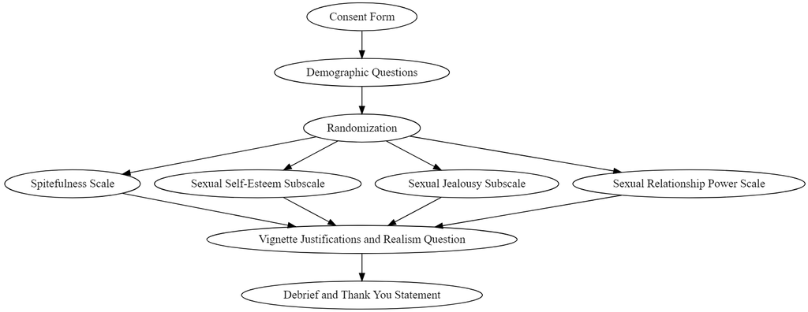

# Demographics:

Participants took an average 20M 1.57S. There were 82 participants that completed the survey. The average age of participants was right skewed with an average age of 25.61. There was also an over-representation of white individuals as well. On average participants had a University Undergraduate Degree or an A-levels or equivalent qualification. A majority of participants identified as being European as well.

# Demographics:

### Age

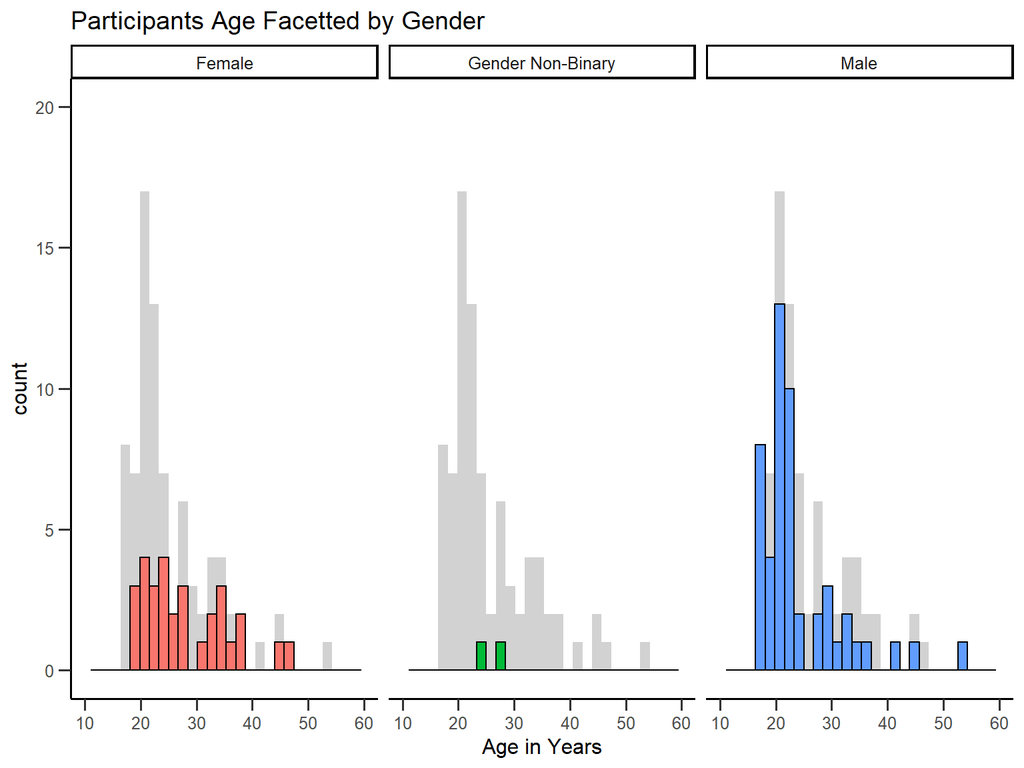

- Majority of participants were younger
- Majority of younger people were male as overall majority was male

*Participant Demographic Information*

|  | Overall |
| --- | --- |
|  | (N=82) |
| **Age** |  |
| Mean (SD) | 25.6 (7.54) |
| Median [Min, Max] | 23.0 [18.0, 53.0] |
| **Gender** |  |
| Female | 30 (36.6%) |
| Gender Non-Binary | 2 (2.4%) |
| Male | 50 (61.0%) |
| **Ethnicity** |  |
| African | 1 (1.2%) |
| Asian or Asian Scottish or Asian British | 3 (3.7%) |
| Mixed or Multiple ethnic origins | 4 (4.9%) |
| White | 74 (90.2%) |
| **Ethnic Origin** |  |
| African | 1 (1.2%) |
| English | 19 (23.2%) |
| European | 56 (68.3%) |
| Latin American | 1 (1.2%) |
| Other | 4 (4.9%) |
| Scottish | 1 (1.2%) |
| **Educational Attainment** |  |
| Primary School | 6 (7.3%) |
| GCSes or Equivalent | 8 (9.8%) |
| A-Levels or Equivalent | 21 (25.6%) |
| University Post-Graduate Program | 9 (11.0%) |
| University Undergraduate Program | 36 (43.9%) |
| Doctoral Degree | 2 (2.4%) |

# Demographics:

### Gender

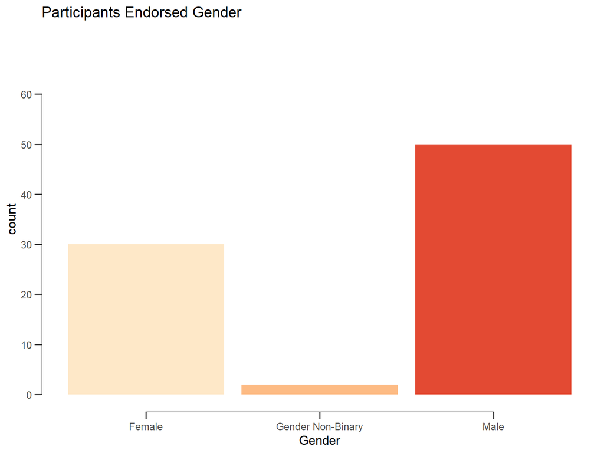

*Participant Demographic Information*

|  | Overall |
| --- | --- |
|  | (N=82) |
| **Age** |  |
| Mean (SD) | 25.6 (7.54) |
| Median [Min, Max] | 23.0 [18.0, 53.0] |
| **Gender** |  |
| Female | 30 (36.6%) |
| Gender Non-Binary | 2 (2.4%) |
| Male | 50 (61.0%) |
| **Ethnicity** |  |
| African | 1 (1.2%) |
| Asian or Asian Scottish or Asian British | 3 (3.7%) |
| Mixed or Multiple ethnic origins | 4 (4.9%) |
| White | 74 (90.2%) |
| **Ethnic Origin** |  |
| African | 1 (1.2%) |
| English | 19 (23.2%) |
| European | 56 (68.3%) |
| Latin American | 1 (1.2%) |
| Other | 4 (4.9%) |
| Scottish | 1 (1.2%) |
| **Educational Attainment** |  |
| Primary School | 6 (7.3%) |
| GCSes or Equivalent | 8 (9.8%) |
| A-Levels or Equivalent | 21 (25.6%) |
| University Post-Graduate Program | 9 (11.0%) |
| University Undergraduate Program | 36 (43.9%) |
| Doctoral Degree | 2 (2.4%) |

# Demographics:

### Education

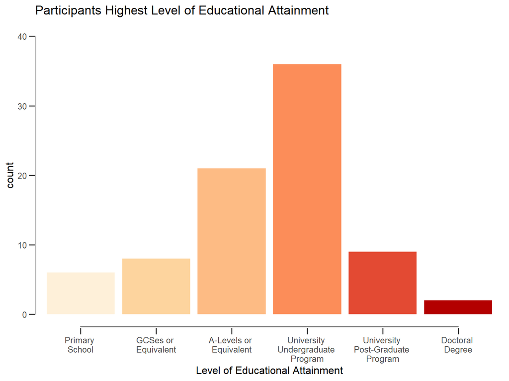

- Majority have higher education qualification

*Participant Demographic Information*

|  | Overall |
| --- | --- |
|  | (N=82) |
| **Age** |  |
| Mean (SD) | 25.6 (7.54) |
| Median [Min, Max] | 23.0 [18.0, 53.0] |
| **Gender** |  |
| Female | 30 (36.6%) |
| Gender Non-Binary | 2 (2.4%) |
| Male | 50 (61.0%) |
| **Ethnicity** |  |
| African | 1 (1.2%) |
| Asian or Asian Scottish or Asian British | 3 (3.7%) |
| Mixed or Multiple ethnic origins | 4 (4.9%) |
| White | 74 (90.2%) |
| **Ethnic Origin** |  |
| African | 1 (1.2%) |
| English | 19 (23.2%) |
| European | 56 (68.3%) |
| Latin American | 1 (1.2%) |
| Other | 4 (4.9%) |
| Scottish | 1 (1.2%) |
| **Educational Attainment** |  |
| Primary School | 6 (7.3%) |
| GCSes or Equivalent | 8 (9.8%) |
| A-Levels or Equivalent | 21 (25.6%) |
| University Post-Graduate Program | 9 (11.0%) |
| University Undergraduate Program | 36 (43.9%) |
| Doctoral Degree | 2 (2.4%) |

# Demographics:

### Ethnic Origin

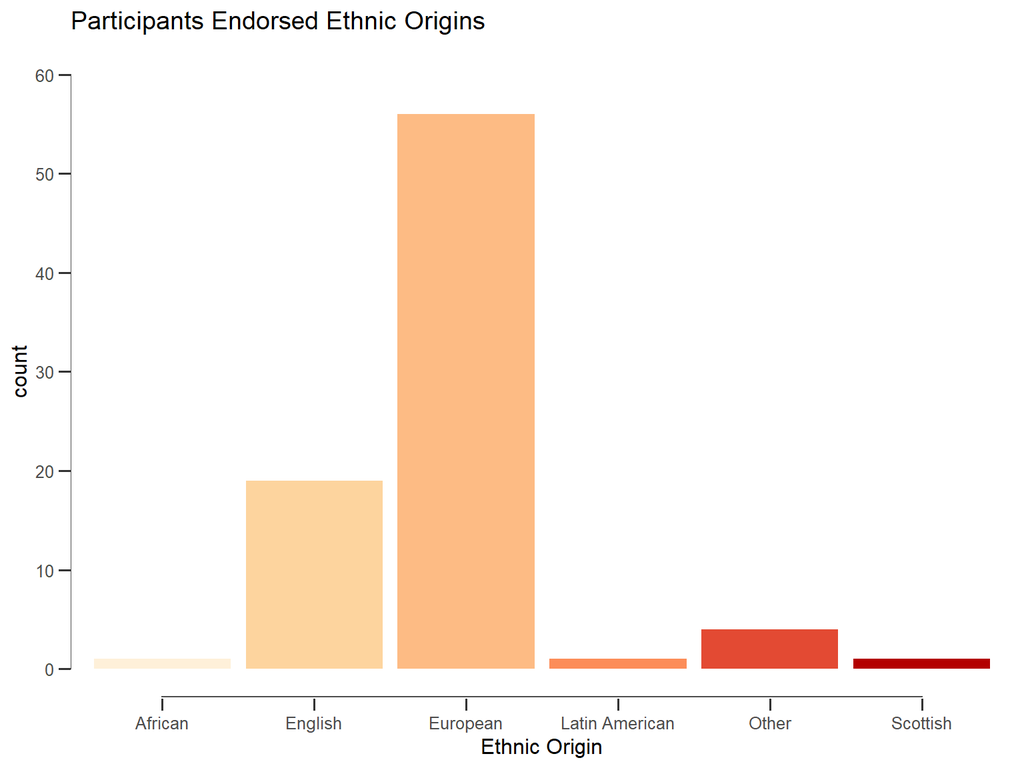

- Overwhelming majority of participants are European

*Participant Demographic Information*

|  | Overall |
| --- | --- |
|  | (N=82) |
| **Age** |  |
| Mean (SD) | 25.6 (7.54) |
| Median [Min, Max] | 23.0 [18.0, 53.0] |
| **Gender** |  |
| Female | 30 (36.6%) |
| Gender Non-Binary | 2 (2.4%) |
| Male | 50 (61.0%) |
| **Ethnicity** |  |
| African | 1 (1.2%) |
| Asian or Asian Scottish or Asian British | 3 (3.7%) |
| Mixed or Multiple ethnic origins | 4 (4.9%) |
| White | 74 (90.2%) |
| **Ethnic Origin** |  |
| African | 1 (1.2%) |
| English | 19 (23.2%) |
| European | 56 (68.3%) |
| Latin American | 1 (1.2%) |
| Other | 4 (4.9%) |
| Scottish | 1 (1.2%) |
| **Educational Attainment** |  |
| Primary School | 6 (7.3%) |
| GCSes or Equivalent | 8 (9.8%) |
| A-Levels or Equivalent | 21 (25.6%) |
| University Post-Graduate Program | 9 (11.0%) |
| University Undergraduate Program | 36 (43.9%) |
| Doctoral Degree | 2 (2.4%) |

# Demographics:

### Ethnicity

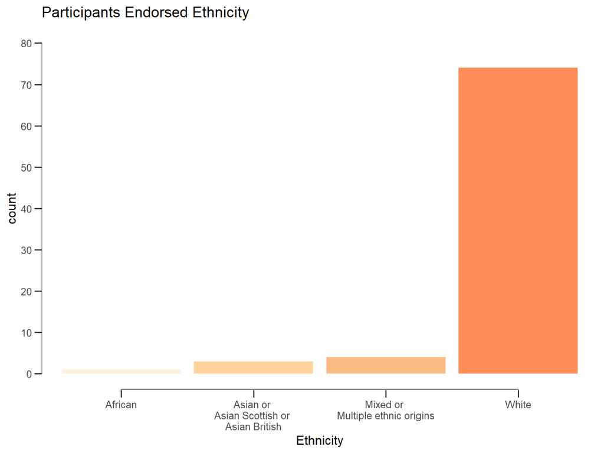

- Overrepresentation of white participants

*Participant Demographic Information*

|  | Overall |
| --- | --- |
|  | (N=82) |
| **Age** |  |
| Mean (SD) | 25.6 (7.54) |
| Median [Min, Max] | 23.0 [18.0, 53.0] |
| **Gender** |  |
| Female | 30 (36.6%) |
| Gender Non-Binary | 2 (2.4%) |
| Male | 50 (61.0%) |
| **Ethnicity** |  |
| African | 1 (1.2%) |
| Asian or Asian Scottish or Asian British | 3 (3.7%) |
| Mixed or Multiple ethnic origins | 4 (4.9%) |
| White | 74 (90.2%) |
| **Ethnic Origin** |  |
| African | 1 (1.2%) |
| English | 19 (23.2%) |
| European | 56 (68.3%) |
| Latin American | 1 (1.2%) |
| Other | 4 (4.9%) |
| Scottish | 1 (1.2%) |
| **Educational Attainment** |  |
| Primary School | 6 (7.3%) |
| GCSes or Equivalent | 8 (9.8%) |
| A-Levels or Equivalent | 21 (25.6%) |
| University Post-Graduate Program | 9 (11.0%) |
| University Undergraduate Program | 36 (43.9%) |
| Doctoral Degree | 2 (2.4%) |

# Spitefulness:

### Gender

Endorsement of spiteful behavior follow expected distributions with a majority of individuals scoring median = 36.00 and mean = 34.78.

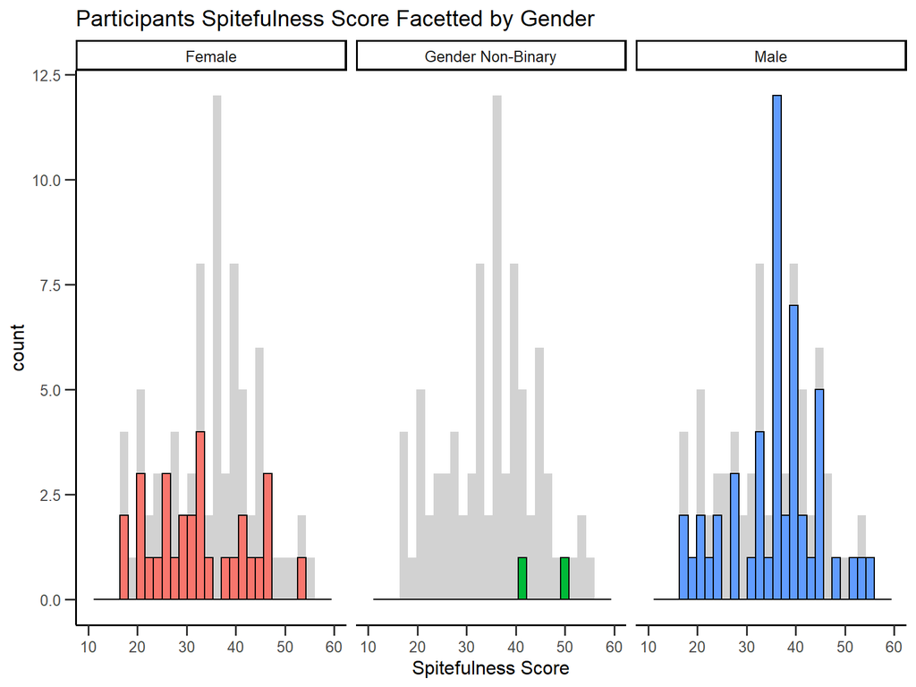

# Spitefulness:

### Age Distribution

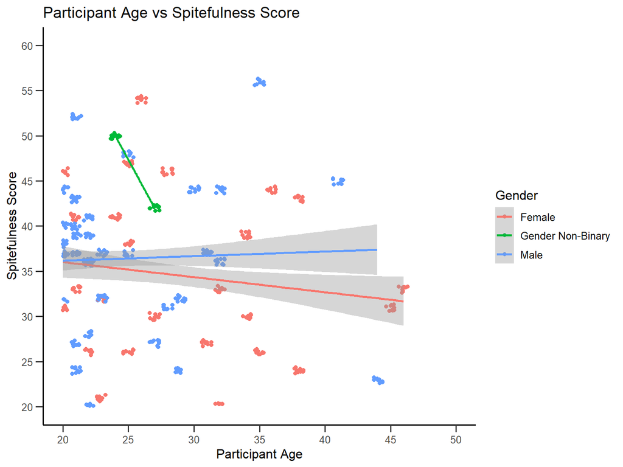

- Clustering of participants towards the minimum along with clustering in the mid range of spitefulness scores

# Vignettes:

### Gender

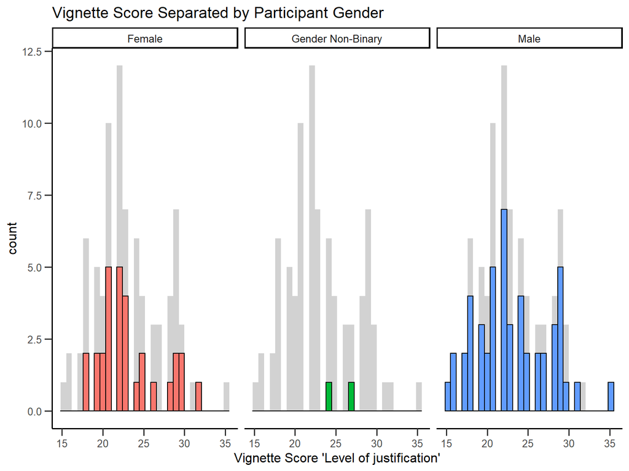

# Vignettes:

### Age

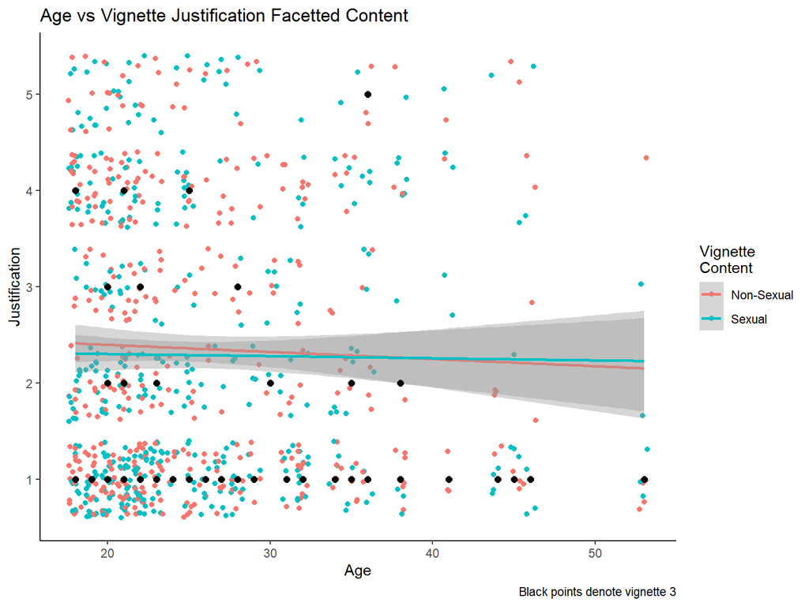

# Vignettes:

### Education

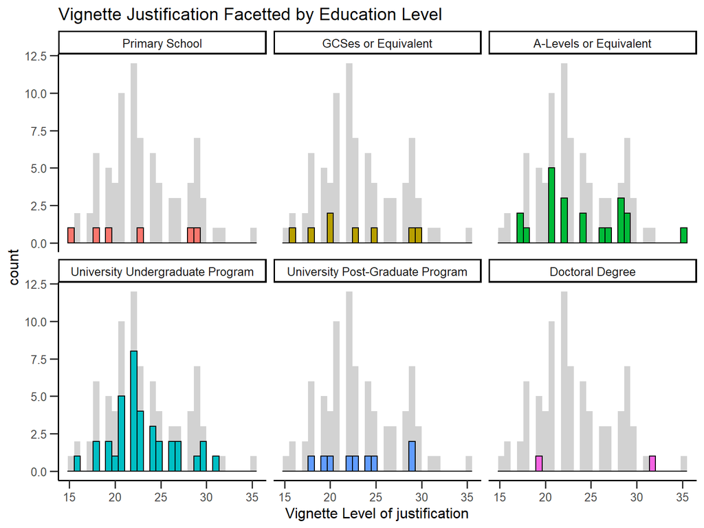

# Vignettes:

### Realism

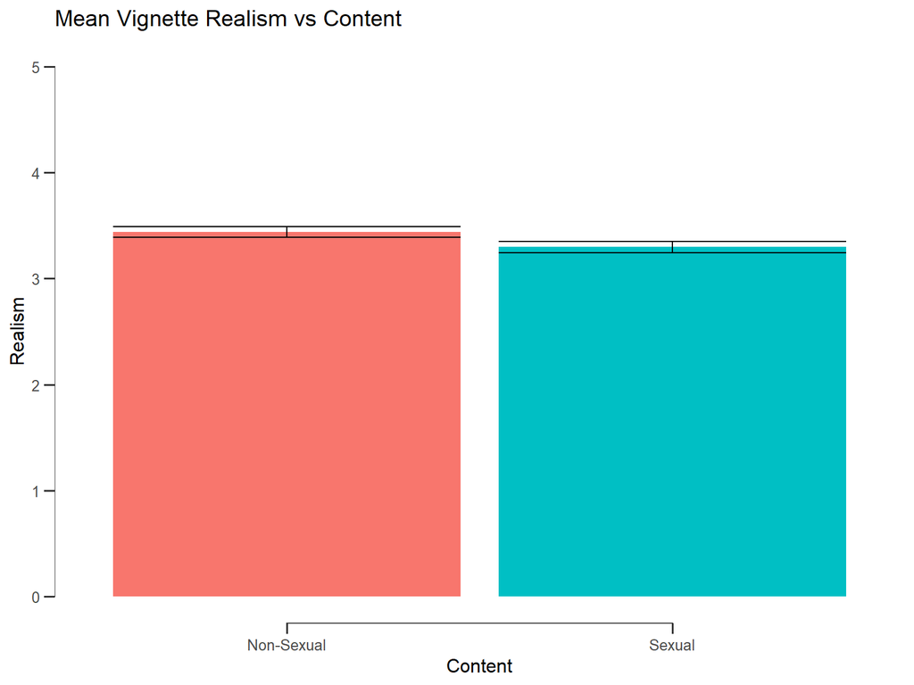

# Preliminary Analyses

In the preliminary analysis, I investigated the effect that spitefulness and content type had on the the level of justification of the spiteful vignettes. In the original analysis there was one vignette that was an outlier, vignette 3. A majority of participants judged the justification of the spiteful act as ‘unjustified’ and ‘not justified at all.’ In the the ggplot below, there appears to be a possible interaction between spitefulness and content type. However, from both the Bayesian analysis and the simple regression (see below) the interaction appears to be rather low. This is a possible indication that there is an effect, be it small, of spitefulness and the content type and later justification of the behaviors. However, there does appear to be a conflict with the vignettes themselves, where some of the vignettes are darker than others and thus a majority of participants judge them negatively.

*Descriptive Statistics for Vignette Justifications*

| Vignette | $M$ | $SD$ |
| --- | --- | --- |
| 1 | 3.94 | 1.21 |
| 2 | 2.13 | 1.20 |
| 3 | 1.34 | 0.86 |
| 4 | 1.56 | 0.94 |
| 5 | 1.55 | 0.79 |
| 6 | 3.83 | 1.02 |
| 7 | 1.65 | 1.05 |
| 8 | 1.78 | 1.08 |
| 9 | 3.28 | 1.19 |
| 10 | 2.17 | 1.20 |

*Descriptive Statistics For Overall Vignette Justification Grouped by Content*

| Vignette Content | $M$ | $SD$ |
| --- | --- | --- |
| Sexual | 2.29 | 1.41 |
| Non-Sexual | 2.36 | 1.41 |

# Preliminary Analyses:

### Vignette Example

[output not shown]

All the vignettes have a common thread of spiteful reactions to certain behavior patterns and causes. However, some like the above, are devoid of sexual activity and are therefore a representation of the other four vignettes that are non-sexual. The above average justification score was 1.78

# Preliminary Analyses:

### Vignette Justification: Violin Plot

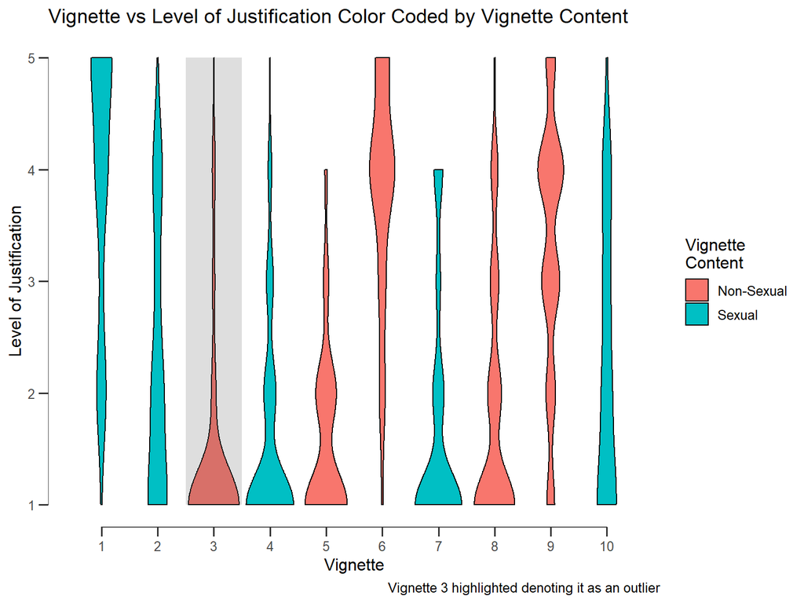

# Regression Plot

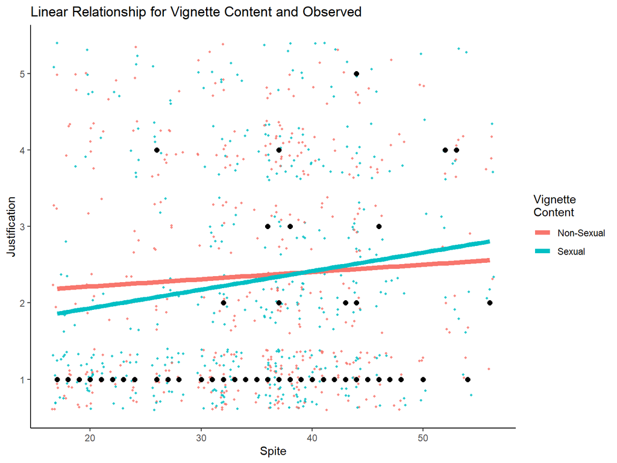

# Bayesian Statistical Analysis

*Bayesian Multilevel Model with Predictors, Estimates, and Confidence Intervals*

[output not shown]

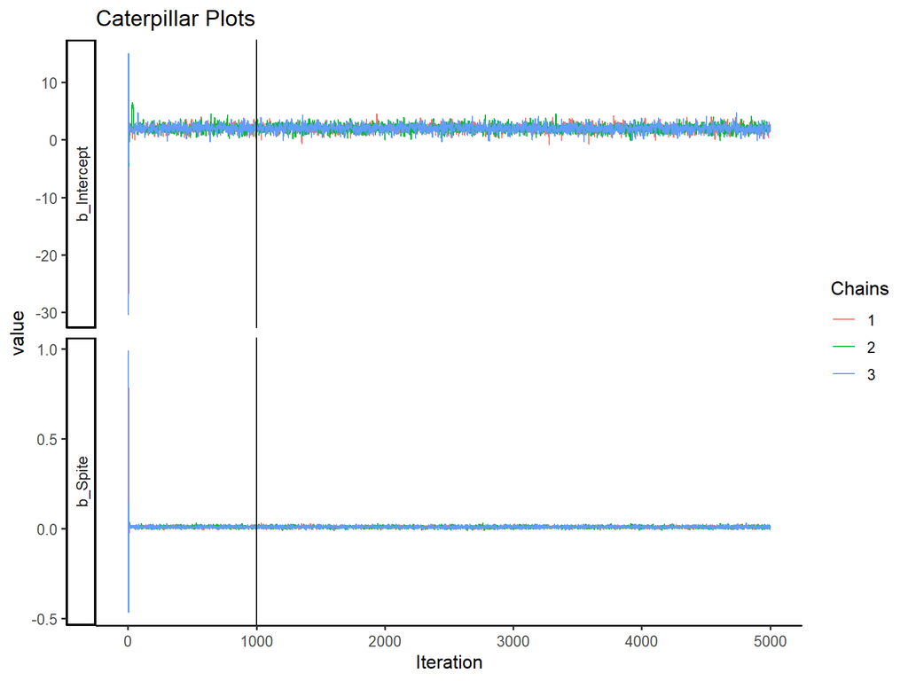

# Future Directions:

### The Vignettes

I intend to have a larger focus on the vignettes themselves. I intend to write a large amount of vignettes, more than the original 10 for the first study. I intend to again write a mixture of sexual and non-sexual vignettes. In addition, I intend to write them as having a mixture of careless actions and intentional behaviors.

After I have written a good amount of vignettes I want to pilot the vignettes on their own to get a majority response on the vignettes to get a range of responses so that there is one or more vignettes that were universally derided, e.g., vignette 3. I would like to do this multiple times, possibly through the research pool to save money.

# Future Directions:

### Data collection

I would like to have a combination of Qualtrics and pavlovia.org’s data collection procedures. Qualtrics is good for the randomization and quick data collection and pavlovia.org and psychojs are good with having accurate timing, which was a limitation of this first study. I would have survey information through Qualtrics and the experimental session hosted on pavlovia.org. I aim to have the piloting start in September and hopefully data collection for the official second study in October/November. I will also be in the near future applying for another small research grant. I might also look at outside funding as well, if the economy allows for it.

[figure not shown]

[figure not shown]

# Future Directions:

### Skills

I want to work on my python, R, JavaScript, and Bayesian statistics skills. I want to see what more I can do with python and JavaScript and see how much I can automate some processes. I also want to develop more my presentation skill. I will be looking in the near future to apply and hopefully present at multiple conferences with the data that I have with conferences like Association for Psychological Science, British Psychological Society and so on.

# Future Directions:

### Skills thus far

I have developed in my knowledge of R. Over the course of the first year I have taken the univariate and multivariate R courses. I have learned RMarkdown and shiny as well, (see app). I have learned python over the course of the last few months and want to further develop my python skills. I want to create a Twitter data mining program to get real time spiteful behaviors around the world and collect certain statistics on that.

# Future Directions:

### Dissertation directions

As of today I have written drafts for the first and part of the second chapter. I intend to have the second chapter draft finished by September. Over the course of the next year I want to have two more chapters finished and a possible paper submitted for publication.

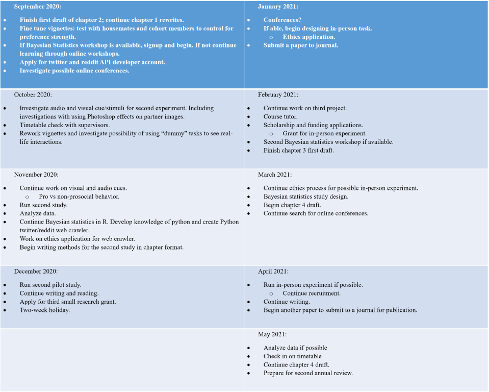